# What Factors Affect Home Ownership?

# IV. Methodology/ Empirical Model

Our main unrestricted model (Model 1) looks as follows:

**Model 1:** $$ownership=\beta_0 + \beta_1*sex + \beta_2*race + \beta_3*marst + \beta_4*famsize + \beta_5*uhrsworkly + \beta_6*educ + \beta_7*age + \beta_8*loginctot + \beta_9*region + u$$

With restricted models (Model 2-6) as well:

We have selected the Linear Probability Model (LPM) primarily for its straightforward interpretability and suitability for our extensive dataset. This model is particularly apt for binary dependent variables, like our variable of interest, home ownership, which is coded as 1 for ownership and 0 otherwise.

The LPM's strength lies in its ability to elucidate the impact of independent variables on the likelihood of home ownership. Specifically, the coefficients in an LPM are interpreted as the change in the probability of the outcome (in this case, owning a home) for each one-unit increase in a regressor. For instance, a coefficient of 0.2 for income would indicate that each additional unit of income raises the probability of owning a home by 20%. This direct interpretation of coefficients as marginal effects offers clear insights into the relationship between various factors and the probability of home ownership.

**Regarding Gauss-Markov Assumptions**

1. **Linearity**: We assume a linear relationship between the dependent and independent variables.
2. **Exogeneity**: While we initially assume exogeneity, there is a potential concern for omitted variable bias, a limitation inherent in our dataset.
3. **No Multicollinearity**: Preliminary analysis indicates no significant multicollinearity (refer to the earlier section). However, we plan to conduct further investigations to confirm this.
4. **Independence and Identically Distributed (i.i.d.)**: We operate under the assumption of i.i.d. random sampling, although the exact methodology of the survey sample selection is unknown to us.
5. **Homoskedasticity**: Although homoskedasticity is assumed, we intend to test for this later. Regardless, we will employ heteroskedasticity-robust standard errors in our analysis to mitigate potential issues.

**Further Discussion on Assumptions**

- Asymptotic Normality: With our notably large sample size (over 50,000 in each dataset), we rely on the concept of asymptotic normality. This means that, despite the distribution of the underlying variables, the sampling distribution of our estimator is expected to be approximately normal.
- Central Limit Theorem: Given the size of our dataset, the Central Limit Theorem supports the assumption that our Ordinary Least Squares (OLS) estimators will follow a normal distribution. This is crucial for enabling clear and straightforward inferential statistics.
- Implication for Inference: As a result of these considerations, we can confidently proceed with our analysis, assuming asymptotic normality for the purposes of inference. This assumption simplifies the process of drawing conclusions from our model.

## a. Economic Hypotheses

In our analysis, several key variables are considered for their potential impact on home ownership:

**Sex (SEX)**: Given the persistent wage gap and societal roles, sex is included as a regressor. Historically, men have earned higher incomes on average, which could facilitate easier access to homeownership.

**Race (RACE)**: This variable is crucial for understanding systemic disparities in housing markets, often rooted in historical discrimination. These disparities have influenced credit access and wealth accumulation, potentially leading to different homeownership rates among racial groups.

**Marital Status (MARST)**: Marital status is likely to influence economic stability and wealth accumulation. Married couples, often benefiting from dual incomes and larger savings, may exhibit higher homeownership rates.

**Family Size (FAMSIZE)**: The number of family members in a household, as suggested by research from Wellesley College, can impact homeownership. Larger families might prioritize stable and spacious living arrangements, though the associated costs could also pose a barrier to homeownership.

**Usual Hours Worked Weekly (UHRSWORKLY)**: This serves as an indicator of income and job stability. We hypothesize that full-time employment, reflecting more hours worked, is positively associated with homeownership due to higher earnings and stability.

**Age (AGE)**: Age may be indicative of wealth accumulation and mortgage repayment progress. Older individuals are likely to have more stable incomes and savings, thus a higher likelihood of owning homes.

**Log Total Personal Income (LOGINCTOT)**: Income directly affects purchasing power for a home. The log transformation of income is expected to linearize its relationship with homeownership, suggesting that higher incomes increase the likelihood of owning a home.

**Region (REGION)**: Geographic factors like home prices, local economies, and employment opportunities vary by region and can significantly impact homeownership rates. We anticipate regional differences in homeownership, influenced by factors like cost of living and local economic conditions.

# V. Regression Analysis

## a. Multicollinearity

To test whether there exists any mulicollinearity, we looked into Variance Inflation Factor (VIF).

```python
# Import package
from statsmodels.stats.outliers_influence import variance_inflation_factor

# Make a copy of the regressors
X07 = cps2007.drop('OWNERSHP', axis=1).copy()
# Set intercept
X07['Intercept'] = 1

vif07 = pd.DataFrame()
vif07['variable'] = X07.columns
# Calculate VIF for each independent variable
vif07['VIF'] = [variance_inflation_factor(X07.values, i) for i in range(X07.shape[1])]

vif07 = vif07[vif07['variable'] != 'Intercept']

vif07.round(2)
```

|  | variable | VIF |
| --- | --- | --- |
| 0 | REGION | 1.01 |
| 1 | AGE | 1.12 |
| 2 | SEX | 1.18 |
| 3 | RACE | 1.03 |
| 4 | MARST | 1.49 |
| 5 | FAMSIZE | 1.42 |
| 6 | EDUC | 1.11 |
| 7 | UHRSWORKLY | 1.23 |
| 8 | INCTOT | 2.04 |
| 9 | LOGINCTOT | 2.41 |

```python
# Make a copy of the regressors
X09 = cps2009.drop('OWNERSHP', axis=1).copy()
# Set intercept
X09['Intercept'] = 1

vif09 = pd.DataFrame()
vif09['variable'] = X09.columns
# Calculate VIF for each independent variable
vif09['VIF'] = [variance_inflation_factor(X09.values, i) for i in range(X09.shape[1])]

vif09 = vif09[vif09['variable'] != 'Intercept']

vif09.round(2)
```

|  | variable | VIF |
| --- | --- | --- |
| 0 | REGION | 1.01 |
| 1 | AGE | 1.13 |
| 2 | SEX | 1.16 |
| 3 | RACE | 1.03 |
| 4 | MARST | 1.48 |
| 5 | FAMSIZE | 1.42 |
| 6 | EDUC | 1.12 |
| 7 | UHRSWORKLY | 1.26 |
| 8 | INCTOT | 2.22 |
| 9 | LOGINCTOT | 2.62 |

#### **Interpretation**

Our analysis indicates no concerning level of multicollinearity, with all variables having a VIF below 5. This suggests that each variable contributes distinct information to the model, allowing us to proceed without the need to remove or merge variables for addressing multicollinearity concerns.

The lack of significant multicollinearity also implies that the regression coefficients can be interpreted as independently influencing the likelihood of home ownership. This clarity in interpretation enhances the reliability of our analysis in understanding how each variable individually affects home ownership probabilities.

## b. Ordinary Least Squared (OLS) Linear Regression

### Preliminary Regression for 2007 Data (Unrestricted and Restricted)

We conducted an Ordinary Least Squares (OLS) linear regression analysis using various model specifications, including an unrestricted model and five restricted models. This approach enables us to examine how the inclusion of each variable enhances the explanatory power of the models. For simplicity and focus, we limited this multi-specification analysis to the 2007 data set, as our primary objective in this part is not to compare the 2007 and 2009 data, but rather to understand the factors influencing outcomes within a single year's data.

```python
# OLS Models with Different Specifications with 2007 Data
m1 = smf.ols(formula="OWNERSHP ~ FAMSIZE + UHRSWORKLY +  LOGINCTOT + C(REGION)", data=cps2007).fit()
m2 = smf.ols(formula="OWNERSHP ~ FAMSIZE + UHRSWORKLY +  LOGINCTOT + C(REGION) + SEX", data=cps2007).fit()
m3 = smf.ols(formula="OWNERSHP ~ FAMSIZE + UHRSWORKLY +  LOGINCTOT + C(REGION) + SEX + RACE", data=cps2007).fit()
m4 = smf.ols(formula="OWNERSHP ~ FAMSIZE + UHRSWORKLY +  LOGINCTOT + C(REGION) + SEX + RACE + MARST", data=cps2007).fit()
m5 = smf.ols(formula="OWNERSHP ~ FAMSIZE + UHRSWORKLY +  LOGINCTOT + C(REGION) + SEX + RACE + MARST + EDUC", data=cps2007).fit()
m6 = smf.ols(formula="OWNERSHP ~ FAMSIZE + UHRSWORKLY +  LOGINCTOT + C(REGION) + SEX + RACE + MARST + EDUC + AGE", data=cps2007).fit()

table = Stargazer([m1, m2, m3, m4, m5, m6])
table.covariate_order(['Intercept', 'FAMSIZE', 'UHRSWORKLY', 'LOGINCTOT', 'C(REGION)[T.1]', 'C(REGION)[T.2]', 'C(REGION)[T.3]', 'SEX', 'RACE', 'MARST', 'EDUC', 'AGE'])
table.rename_covariates({'SEX':'SEX (=1 if Female)', 'RACE':'RACE (=1 if Non-White)', 'MARST':'MARST (=1 if Single)', 'EDUC':'EDUC (=1 if College Educated)', 'C(REGION)[T.1]':'Midwest Region', 'C(REGION)[T.2]':'South Region', 'C(REGION)[T.3]':'West Region'})
HTML(table.render_html())
```

|  | *Dependent variable: OWNERSHP* |  |  |  |  |  |
| --- | --- | --- | --- | --- | --- | --- |
|  | (1) | (2) | (3) | (4) | (5) | (6) |
| Intercept | -0.838*** | -0.828*** | -0.778*** | -0.439*** | -0.383*** | -0.653*** |
|  | (0.022) | (0.023) | (0.023) | (0.023) | (0.023) | (0.022) |
| FAMSIZE | 0.059*** | 0.059*** | 0.057*** | 0.014*** | 0.016*** | 0.037*** |
|  | (0.001) | (0.001) | (0.001) | (0.001) | (0.001) | (0.001) |
| UHRSWORKLY | -0.002*** | -0.002*** | -0.002*** | -0.001*** | -0.001*** | 0.000 |
|  | (0.000) | (0.000) | (0.000) | (0.000) | (0.000) | (0.000) |
| LOGINCTOT | 0.138*** | 0.137*** | 0.134*** | 0.120*** | 0.110*** | 0.079*** |
|  | (0.002) | (0.002) | (0.002) | (0.002) | (0.002) | (0.002) |
| Midwest Region | 0.055*** | 0.055*** | 0.053*** | 0.050*** | 0.049*** | 0.062*** |
|  | (0.006) | (0.006) | (0.006) | (0.006) | (0.005) | (0.005) |
| South Region | 0.024*** | 0.024*** | 0.042*** | 0.036*** | 0.037*** | 0.047*** |
|  | (0.005) | (0.005) | (0.005) | (0.005) | (0.005) | (0.005) |
| West Region | -0.037*** | -0.038*** | -0.031*** | -0.029*** | -0.030*** | -0.020*** |
|  | (0.006) | (0.006) | (0.006) | (0.005) | (0.005) | (0.005) |
| SEX (=1 if Female) |  | -0.005 | 0.003 | 0.052*** | 0.044*** | 0.038*** |
|  |  | (0.004) | (0.004) | (0.004) | (0.004) | (0.004) |
| RACE (=1 if Non-White) |  |  | -0.149*** | -0.117*** | -0.118*** | -0.117*** |
|  |  |  | (0.005) | (0.005) | (0.005) | (0.004) |
| MARST (=1 if Single) |  |  |  | -0.270*** | -0.266*** | -0.213*** |
|  |  |  |  | (0.004) | (0.004) | (0.004) |
| EDUC (=1 if College Educated) |  |  |  |  | 0.061*** | 0.077*** |
|  |  |  |  |  | (0.004) | (0.004) |
| AGE |  |  |  |  |  | 0.010*** |
|  |  |  |  |  |  | (0.000) |
| Observations | 54279 | 54279 | 54279 | 54279 | 54279 | 54279 |
| R<sup>2</sup> | 0.109 | 0.109 | 0.125 | 0.183 | 0.187 | 0.252 |
| Adjusted R<sup>2</sup> | 0.109 | 0.109 | 0.125 | 0.183 | 0.186 | 0.252 |
| Residual Std. Error | 0.436 (df=54272) | 0.436 (df=54271) | 0.432 (df=54270) | 0.417 (df=54269) | 0.416 (df=54268) | 0.399 (df=54267) |
| F Statistic | 1106.375*** (df=6; 54272) | 948.600*** (df=7; 54271) | 967.342*** (df=8; 54270) | 1349.240*** (df=9; 54269) | 1244.622*** (df=10; 54268) | 1663.843*** (df=11; 54267) |
| Note: | *p<0.1; **p<0.05; ***p<0.01 |  |  |  |  |  |

### Preliminary Unrestricted Regressions for 2007 and 2009 Data

We conducted separate OLS regression analyses on the 2007 and 2009 data sets to explore our primary objective: determining whether the factors influencing home ownership shifted during the Great Recession. This analysis is preliminary, as it does not yet account for potential heteroskedasticity in the data. Addressing this issue will be crucial for refining our understanding of how the recession may have altered the dynamics of home ownership.

```python
# OLS Models
m07 = smf.ols(formula="OWNERSHP ~ SEX + RACE + MARST + FAMSIZE + UHRSWORKLY + EDUC + AGE + LOGINCTOT + C(REGION)", data=cps2007)
m09 = smf.ols(formula="OWNERSHP ~ SEX + RACE + MARST + FAMSIZE + UHRSWORKLY + EDUC + AGE + LOGINCTOT + C(REGION)", data=cps2009)

result1 = m07.fit()
result2 = m09.fit()

ms = Stargazer([result1,result2])
ms.custom_columns(['2007', '2009'], [1, 1])
ms.covariate_order(['Intercept', 'FAMSIZE', 'UHRSWORKLY', 'LOGINCTOT', 'C(REGION)[T.1]', 'C(REGION)[T.2]', 'C(REGION)[T.3]', 'SEX', 'RACE', 'MARST', 'EDUC', 'AGE'])
ms.rename_covariates({'SEX':'SEX (=1 if Female)', 'RACE':'RACE (=1 if Non-White)', 'MARST':'MARST (=1 if Single)', 'EDUC':'EDUC (=1 if College Educated)', 'C(REGION)[T.1]':'Midwest Region', 'C(REGION)[T.2]':'South Region', 'C(REGION)[T.3]':'West Region'})
HTML(ms.render_html())
```

|  | *Dependent variable: OWNERSHP* |  |
| --- | --- | --- |
|  | 2007 | 2009 |
|  | (1) | (2) |
| Intercept | -0.653*** | -0.634*** |
|  | (0.022) | (0.023) |
| FAMSIZE | 0.037*** | 0.033*** |
|  | (0.001) | (0.001) |
| UHRSWORKLY | 0.000 | 0.000 |
|  | (0.000) | (0.000) |
| LOGINCTOT | 0.079*** | 0.077*** |
|  | (0.002) | (0.002) |
| Midwest Region | 0.062*** | 0.050*** |
|  | (0.005) | (0.005) |
| South Region | 0.047*** | 0.040*** |
|  | (0.005) | (0.005) |
| West Region | -0.020*** | -0.028*** |
|  | (0.005) | (0.005) |
| SEX (=1 if Female) | 0.038*** | 0.033*** |
|  | (0.004) | (0.004) |
| RACE (=1 if Non-White) | -0.117*** | -0.131*** |
|  | (0.004) | (0.004) |
| MARST (=1 if Single) | -0.213*** | -0.212*** |
|  | (0.004) | (0.004) |
| EDUC (=1 if College Educated) | 0.077*** | 0.081*** |
|  | (0.004) | (0.004) |
| AGE | 0.010*** | 0.010*** |
|  | (0.000) | (0.000) |
| Observations | 54279 | 54484 |
| R<sup>2</sup> | 0.252 | 0.250 |
| Adjusted R<sup>2</sup> | 0.252 | 0.249 |
| Residual Std. Error | 0.399 (df=54267) | 0.404 (df=54472) |
| F Statistic | 1663.843*** (df=11; 54267) | 1646.819*** (df=11; 54472) |
| Note: | *p<0.1; **p<0.05; ***p<0.01 |  |

## c. Heteroskedasticity

### Breusch-Pagan Test

We employed the Breusch-Pagan test to evaluate the presence of heteroskedasticity in our models. The test is framed around the following hypotheses:

> $H_0:$ Homoscedasticity is present (the residuals are distributed with equal variance).

> $H_1:$ Heteroscedasticity is present (the residuals are not distributed with equal variance).

**Breusch-Pagan Test Test for 2007 Data**

```python
import statsmodels.stats.api as sms
from statsmodels.compat import lzip

test1 = sms.het_breuschpagan(result1.resid, result1.model.exog)
name = ['LM statistic', 'LM Test p-value', 'F-Statistic', 'F-Test p-value']
pd.DataFrame(lzip(name,test1))
```

|  | 0 | 1 |
| --- | --- | --- |
| 0 | LM statistic | 4649.152691 |
| 1 | LM Test p-value | 0.000000 |
| 2 | F-Statistic | 462.140467 |
| 3 | F-Test p-value | 0.000000 |

**Breusch-Pagan Test for 2009 Data**

```python
test2 = sms.het_breuschpagan(result2.resid, result2.model.exog)
pd.DataFrame(lzip(name,test2))
```

|  | 0 | 1 |
| --- | --- | --- |
| 0 | LM statistic | 4272.38888 |
| 1 | LM Test p-value | 0.00000 |
| 2 | F-Statistic | 421.35413 |
| 3 | F-Test p-value | 0.00000 |

#### **Interpretation**

The results from the test, including both the Lagrange multiplier statistic and the F-statistic, were significantly high. Moreover, the associated p-values were less than 0.05, indicating statistical significance well within conventional thresholds (e.g., p < 0.05).

These outcomes lead us to reject the null hypothesis and accept the alternative hypothesis, confirming evidence of heteroskedasticity in the residuals of both models. This means that the variance of the error terms is not consistent across observations.

In light of these findings, our decision to use heteroskedasticity-robust standard errors below, specifically with cov_type='HC3', is both appropriate and necessary to ensure the robustness of our regression analysis.

### OLS Regression with Heteroskedasticity-Robust Standard Errors

```python
result1robust = m07.fit(cov_type='HC3')
result2robust = m09.fit(cov_type='HC3')

ms1 = Stargazer([result1,result1robust, result2, result2robust])
ms1.custom_columns(['2007', '2007 (Robust)', '2009', '2009 (Robust)'], [1, 1, 1, 1])
ms1.covariate_order(['Intercept', 'FAMSIZE', 'UHRSWORKLY', 'LOGINCTOT', 'C(REGION)[T.1]', 'C(REGION)[T.2]', 'C(REGION)[T.3]', 'SEX', 'RACE', 'MARST', 'EDUC', 'AGE'])
ms1.rename_covariates({'SEX':'SEX (=1 if Female)', 'RACE':'RACE (=1 if Non-White)', 'MARST':'MARST (=1 if Single)', 'EDUC':'EDUC (=1 if College Educated)', 'C(REGION)[T.1]':'Midwest Region', 'C(REGION)[T.2]':'South Region', 'C(REGION)[T.3]':'West Region'})
HTML(ms1.render_html())
```

|  | *Dependent variable: OWNERSHP* |  |  |  |
| --- | --- | --- | --- | --- |
|  | 2007 | 2007 (Robust) | 2009 | 2009 (Robust) |
|  | (1) | (2) | (3) | (4) |
| Intercept | -0.653*** | -0.653*** | -0.634*** | -0.634*** |
|  | (0.022) | (0.025) | (0.023) | (0.025) |
| FAMSIZE | 0.037*** | 0.037*** | 0.033*** | 0.033*** |
|  | (0.001) | (0.001) | (0.001) | (0.001) |
| UHRSWORKLY | 0.000 | 0.000 | 0.000 | 0.000 |
|  | (0.000) | (0.000) | (0.000) | (0.000) |
| LOGINCTOT | 0.079*** | 0.079*** | 0.077*** | 0.077*** |
|  | (0.002) | (0.002) | (0.002) | (0.002) |
| Midwest Region | 0.062*** | 0.062*** | 0.050*** | 0.050*** |
|  | (0.005) | (0.005) | (0.005) | (0.005) |
| South Region | 0.047*** | 0.047*** | 0.040*** | 0.040*** |
|  | (0.005) | (0.005) | (0.005) | (0.005) |
| West Region | -0.020*** | -0.020*** | -0.028*** | -0.028*** |
|  | (0.005) | (0.005) | (0.005) | (0.005) |
| SEX (=1 if Female) | 0.038*** | 0.038*** | 0.033*** | 0.033*** |
|  | (0.004) | (0.004) | (0.004) | (0.004) |
| RACE (=1 if Non-White) | -0.117*** | -0.117*** | -0.131*** | -0.131*** |
|  | (0.004) | (0.005) | (0.004) | (0.005) |
| MARST (=1 if Single) | -0.213*** | -0.213*** | -0.212*** | -0.212*** |
|  | (0.004) | (0.005) | (0.004) | (0.005) |
| EDUC (=1 if College Educated) | 0.077*** | 0.077*** | 0.081*** | 0.081*** |
|  | (0.004) | (0.004) | (0.004) | (0.004) |
| AGE | 0.010*** | 0.010*** | 0.010*** | 0.010*** |
|  | (0.000) | (0.000) | (0.000) | (0.000) |
| Observations | 54279 | 54279 | 54484 | 54484 |
| R<sup>2</sup> | 0.252 | 0.252 | 0.250 | 0.250 |
| Adjusted R<sup>2</sup> | 0.252 | 0.252 | 0.249 | 0.249 |
| Residual Std. Error | 0.399 (df=54267) | 0.399 (df=54267) | 0.404 (df=54472) | 0.404 (df=54472) |
| F Statistic | 1663.843*** (df=11; 54267) | 1907.448*** (df=11; 54267) | 1646.819*** (df=11; 54472) | 1918.855*** (df=11; 54472) |
| Note: | *p<0.1; **p<0.05; ***p<0.01 |  |  |  |

#### **Interpretation**

Our regression analysis reveals significant relationships between various predictors and home ownership. Key variables such as age, education, race, region, family size, marital status, and log-transformed income show statistically significant coefficients, highlighting their impact on home ownership likelihood.

**Regression Parameters Interpretation**

**Model Fit** The R-squared values, approximately 0.252 for 2007 and 0.250 for 2009, suggest that around a quarter of the variance in home ownership status is explained by the model's independent variables. Given the complexity of factors influencing home ownership, achieving a very high R-squared is challenging. These R-squared values are in line with expectations from similar research (Goodman and Mayer).

**F-Statistic** The high F-statistics, significant at the 1% level for both years, allow us to reject the null hypothesis that a model without independent variables fits the data as well. The significant coefficients of many independent variables, as indicated by the p-values with asterisks, lead us to reject the null hypothesis for these variables, confirming their statistical impact on home ownership probability.

## d. Normality of Residuals

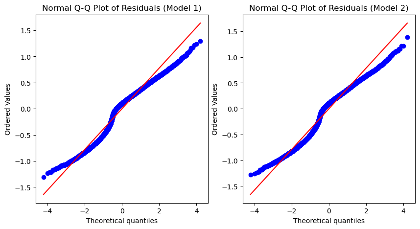

```python
from scipy import stats

fig, ax = plt.subplots(nrows=1, ncols=2, figsize=(10, 5))

stats.probplot(result1robust.resid, plot=ax[0])
ax[0].set_title("Normal Q-Q Plot of Residuals (Model 1)")

stats.probplot(result2robust.resid, plot=ax[1])
ax[1].set_title("Normal Q-Q Plot of Residuals (Model 2)")

plt.show()
```

#### **Interpretation**

However, it's important to consider the implications of the Central Limit Theorem (CLT) in this context. The CLT posits that, for large sample sizes, the distribution of the sample mean will approach a normal distribution, regardless of the shape of the population distribution. This theorem is particularly relevant in regression analysis, as it supports the validity of inferential statistics based on large samples, even if the underlying assumptions, such as normality of residuals, are not perfectly met.

# VI. Conclusion and Discussion

Our study embarked on an empirical journey to unravel the determinants of home ownership in the United States, with a particular focus on the Great Recession period. By employing a Linear Probability Model (LPM), we have illuminated the intricate relationships between home ownership and various socioeconomic factors.

#### Key Findings

- **Age as a Positive Determinant**: Our analysis reaffirmed that age is a consistently positive determinant of home ownership. Notably, the recession did not significantly alter this relationship.
- **Education's Role**: The positive correlation between higher educational levels and home ownership was evident, and this relationship exhibited a slight increase during the recession period.
- **Racial Disparities**: The study highlighted ongoing racial disparities in home ownership, with non-white individuals less likely to own homes. The recession only marginally affected this dynamic.
- **Geographical Variations**: Regional differences in home ownership rates were apparent, potentially reflecting economic and policy disparities.
- **Gender Influence**: While sex had a minimal impact on homeownership, we observed a slight decrease in female home ownership from 2007 to 2009.
- **Marital Status, Income, Family Size**: These variables also demonstrated significant effects on home ownership, in line with our expectations.

Overall, our findings suggest that the determinants of home ownership underwent slight changes in their influence during the recession, but these changes were not substantial enough to be considered economically significant.

#### Caveats and Limitations

- **Omitted Variable Bias**: Our model may suffer from omitted variable bias due to the exclusion of factors like market interest rates, tax credits, and government subsidies, which could significantly influence home ownership.
- **Risk of Overfittin**g: The inclusion of numerous regressors raises the risk of overfitting, potentially affecting the model's predictive accuracy.
- **Causal Inferences**: Our study's design limits the ability to draw strong causal conclusions.

#### Interpretation Challenges

The discrete nature of the variables presented interpretive challenges. However, the LPM coefficients provided valuable insights into the probability changes in home ownership with respect to changes in the predictors.

#### Directions For Future Work

- **Data Cleaning and Coding**: Improved data cleaning and coding, especially for continuous variables and outliers, are critical.
- **Alternative Model Specifications**: Exploring logistic regression and other models could validate our findings and address the probability outcome's bounded nature.
- **Additional Data**: Incorporating factors like credit scores, wealth measures, and broader economic indicators could enrich the analysis.
- **Potential for Causal Inference**: A Difference-in-Differences approach could be instrumental in future studies for establishing causal relationships.
- **Inclusion of Key Variables**: Future analyses would benefit from including variables like credit scores, interest rates, and wealth/net worth to provide a more comprehensive view of home ownership factors.

In conclusion, our study sheds light on the complex dynamics of home ownership, especially during a tumultuous economic period. While we have made significant strides, the path to a fuller understanding requires ongoing research, refined methodologies, and more comprehensive data. This research lays a solid foundation for future investigations into a topic crucial for individual economic stability and the broader housing market.

# VII. References

*Hood, Jaclyn. "The determinants of home ownership: an application of the human capital investment theory to the home ownership decision." (1999).*

*Schuetz, Jenny. "Rethinking homeownership incentives to improve household financial security and shrink the racial wealth gap." (2020).*

*Khorunzhina, Natalia, and Robert A. Miller. "American Dream Delayed: Shifting Determinants of Homeownership–Preliminary and Incomplete–." (2017).*

*Goodman, Laurie S., and Christopher Mayer. "Homeownership and the American dream." Journal of Economic Perspectives 32.1 (2018): 31-58.*

*Gandelman, Néstor. "Homeownership and gender." Available at SSRN 900354 (2005).*

*Carliner, Geoffrey. "Determinants of home ownership." Land Economics 50.2 (1974): 109-119.*